# Online Retail Exploratory Data Analysis with Python

## Case Study

In this project, I will be working with transactional data from an **[online retail store](https://www.kaggle.com/datasets/vijayuv/onlineretail/data)**. The dataset contains information about customer purchases, including product details, quantities, prices, and timestamps. My task is to explore and analyze this dataset to gain insights into the store's sales trends, customer behavior, and popular products.

Through visualizations and statistical analysis, I will uncover key trends, such as the busiest sales months, best-selling products, and the store's most valuable customers. Ultimately, this project aims to provide actionable insights that can drive strategic business decisions and enhance the store's overall performance in the competitive online retail market.

## Dataset

The dataset you will be working with is the "Online Retail" dataset. It contains transactional data of an online retail store from 2010 to 2011. The dataset is available as a `.xlsx` file named `Online Retail.xlsx`. But I turned it into `.csv` hence I prefer `.csv` in this project. To turn into, you can use Microsoft Excel.

The dataset contains the following columns:

- InvoiceNo: Invoice number of the transaction
- StockCode: Unique code of the product
- Description: Description of the product
- Quantity: Quantity of the product in the transaction
- InvoiceDate: Date and time of the transaction
- UnitPrice: Unit price of the product
- CustomerID: Unique identifier of the customer
- Country: Country where the transaction occurred

## Loading the Data into the DataFrame

```python
import pandas as pd
from pandasql import sqldf
import seaborn as sns
import numpy as np
import matplotlib.pyplot as plt
%matplotlib inline
sns.set(color_codes=True)
```

```python
df = pd.read_csv("Online Retail.csv")
```

```python
df.head(5)
```

|  | InvoiceNo | StockCode | Description | Quantity | InvoiceDate | UnitPrice | CustomerID | Country |
| --- | --- | --- | --- | --- | --- | --- | --- | --- |
| 0 | 536365 | 85123A | WHITE HANGING HEART T-LIGHT HOLDER | 6 | 01/12/2010 08:26 | 2.55 | 17850.0 | United Kingdom |
| 1 | 536365 | 71053 | WHITE METAL LANTERN | 6 | 01/12/2010 08:26 | 3.39 | 17850.0 | United Kingdom |
| 2 | 536365 | 84406B | CREAM CUPID HEARTS COAT HANGER | 8 | 01/12/2010 08:26 | 2.75 | 17850.0 | United Kingdom |
| 3 | 536365 | 84029G | KNITTED UNION FLAG HOT WATER BOTTLE | 6 | 01/12/2010 08:26 | 3.39 | 17850.0 | United Kingdom |
| 4 | 536365 | 84029E | RED WOOLLY HOTTIE WHITE HEART. | 6 | 01/12/2010 08:26 | 3.39 | 17850.0 | United Kingdom |

```python
df.tail(5)
```

|  | InvoiceNo | StockCode | Description | Quantity | InvoiceDate | UnitPrice | CustomerID | Country |
| --- | --- | --- | --- | --- | --- | --- | --- | --- |
| 541904 | 581587 | 22613 | PACK OF 20 SPACEBOY NAPKINS | 12 | 09/12/2011 12:50 | 0.85 | 12680.0 | France |
| 541905 | 581587 | 22899 | CHILDREN'S APRON DOLLY GIRL | 6 | 09/12/2011 12:50 | 2.10 | 12680.0 | France |
| 541906 | 581587 | 23254 | CHILDRENS CUTLERY DOLLY GIRL | 4 | 09/12/2011 12:50 | 4.15 | 12680.0 | France |
| 541907 | 581587 | 23255 | CHILDRENS CUTLERY CIRCUS PARADE | 4 | 09/12/2011 12:50 | 4.15 | 12680.0 | France |
| 541908 | 581587 | 22138 | BAKING SET 9 PIECE RETROSPOT | 3 | 09/12/2011 12:50 | 4.95 | 12680.0 | France |

## The Types of Data

```python
df.info()
```

```
<class 'pandas.core.frame.DataFrame'>
RangeIndex: 541909 entries, 0 to 541908
Data columns (total 8 columns):
 #   Column       Non-Null Count   Dtype
---  ------       --------------   -----
 0   InvoiceNo    541909 non-null  object
 1   StockCode    541909 non-null  object
 2   Description  540455 non-null  object
 3   Quantity     541909 non-null  int64
 4   InvoiceDate  541909 non-null  object
 5   UnitPrice    541909 non-null  float64
 6   CustomerID   406829 non-null  float64
 7   Country      541909 non-null  object
dtypes: float64(2), int64(1), object(5)
memory usage: 33.1+ MB
```

```python
df.describe()
```

|  | Quantity | UnitPrice | CustomerID |
| --- | --- | --- | --- |
| count | 541909.000000 | 541909.000000 | 406829.000000 |
| mean | 9.552250 | 4.611114 | 15287.690570 |
| std | 218.081158 | 96.759853 | 1713.600303 |
| min | -80995.000000 | -11062.060000 | 12346.000000 |
| 25% | 1.000000 | 1.250000 | 13953.000000 |
| 50% | 3.000000 | 2.080000 | 15152.000000 |
| 75% | 10.000000 | 4.130000 | 16791.000000 |
| max | 80995.000000 | 38970.000000 | 18287.000000 |

```python
df.dtypes
```

```
InvoiceNo       object
StockCode       object
Description     object
Quantity         int64
InvoiceDate     object
UnitPrice      float64
CustomerID     float64
Country         object
dtype: object
```

## Dropping the Duplicate Rows

```python
df.shape
```

```
(541909, 8)
```

```python
df.duplicated().sum() # 5268 duplicated values.
```

```
5268
```

```python
df = df.drop_duplicates()
```

```python
df.count()
```

```
InvoiceNo      536641
StockCode      536641
Description    535187
Quantity       536641
InvoiceDate    536641
UnitPrice      536641
CustomerID     401604
Country        536641
dtype: int64
```

## Dropping the Missing & Null Values

```python
df.isnull().sum()
```

```
InvoiceNo           0
StockCode           0
Description      1454
Quantity            0
InvoiceDate         0
UnitPrice           0
CustomerID     135037
Country             0
dtype: int64
```

```python
df = df.dropna() # Missing values
df.count()
```

```
InvoiceNo      401604
StockCode      401604
Description    401604
Quantity       401604
InvoiceDate    401604
UnitPrice      401604
CustomerID     401604
Country        401604
dtype: int64
```

```python
df.isnull().sum()
```

```
InvoiceNo      0
StockCode      0
Description    0
Quantity       0
InvoiceDate    0
UnitPrice      0
CustomerID     0
Country        0
dtype: int64
```

## Detecting Outliers

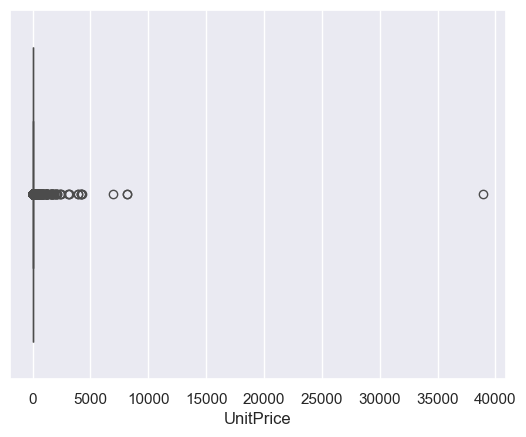

```python
sns.boxplot(x=df['UnitPrice'])
```

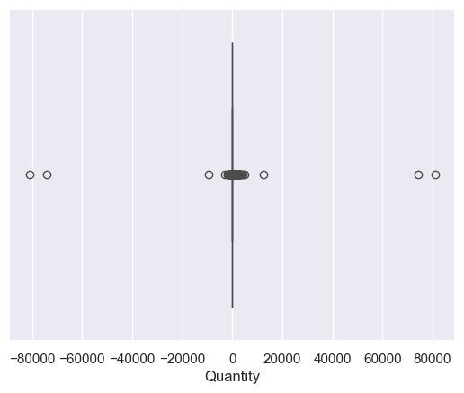

```python
sns.boxplot(x=df['Quantity']) # We have negative quantities; they could be return invoices.
```

```python
negative_values = df[df['Quantity'] < 0]
negative_values # It seems all negative quantities have InvoiceNos starting with 'C', which possibly stands for 'Canceled'.
```

|  | InvoiceNo | StockCode | Description | Quantity | InvoiceDate | UnitPrice | CustomerID | Country |
| --- | --- | --- | --- | --- | --- | --- | --- | --- |
| 141 | C536379 | D | Discount | -1 | 01/12/2010 09:41 | 27.50 | 14527.0 | United Kingdom |
| 154 | C536383 | 35004C | SET OF 3 COLOURED FLYING DUCKS | -1 | 01/12/2010 09:49 | 4.65 | 15311.0 | United Kingdom |
| 235 | C536391 | 22556 | PLASTERS IN TIN CIRCUS PARADE | -12 | 01/12/2010 10:24 | 1.65 | 17548.0 | United Kingdom |
| 236 | C536391 | 21984 | PACK OF 12 PINK PAISLEY TISSUES | -24 | 01/12/2010 10:24 | 0.29 | 17548.0 | United Kingdom |
| 237 | C536391 | 21983 | PACK OF 12 BLUE PAISLEY TISSUES | -24 | 01/12/2010 10:24 | 0.29 | 17548.0 | United Kingdom |
| ... | ... | ... | ... | ... | ... | ... | ... | ... |
| 540449 | C581490 | 23144 | ZINC T-LIGHT HOLDER STARS SMALL | -11 | 09/12/2011 09:57 | 0.83 | 14397.0 | United Kingdom |
| 541541 | C581499 | M | Manual | -1 | 09/12/2011 10:28 | 224.69 | 15498.0 | United Kingdom |
| 541715 | C581568 | 21258 | VICTORIAN SEWING BOX LARGE | -5 | 09/12/2011 11:57 | 10.95 | 15311.0 | United Kingdom |
| 541716 | C581569 | 84978 | HANGING HEART JAR T-LIGHT HOLDER | -1 | 09/12/2011 11:58 | 1.25 | 17315.0 | United Kingdom |
| 541717 | C581569 | 20979 | 36 PENCILS TUBE RED RETROSPOT | -5 | 09/12/2011 11:58 | 1.25 | 17315.0 | United Kingdom |

8872 rows × 8 columns

```python
filtered_df = df[df['InvoiceNo'].str.startswith('C')]
filtered_df
```

|  | InvoiceNo | StockCode | Description | Quantity | InvoiceDate | UnitPrice | CustomerID | Country |
| --- | --- | --- | --- | --- | --- | --- | --- | --- |
| 141 | C536379 | D | Discount | -1 | 01/12/2010 09:41 | 27.50 | 14527.0 | United Kingdom |
| 154 | C536383 | 35004C | SET OF 3 COLOURED FLYING DUCKS | -1 | 01/12/2010 09:49 | 4.65 | 15311.0 | United Kingdom |
| 235 | C536391 | 22556 | PLASTERS IN TIN CIRCUS PARADE | -12 | 01/12/2010 10:24 | 1.65 | 17548.0 | United Kingdom |
| 236 | C536391 | 21984 | PACK OF 12 PINK PAISLEY TISSUES | -24 | 01/12/2010 10:24 | 0.29 | 17548.0 | United Kingdom |
| 237 | C536391 | 21983 | PACK OF 12 BLUE PAISLEY TISSUES | -24 | 01/12/2010 10:24 | 0.29 | 17548.0 | United Kingdom |
| ... | ... | ... | ... | ... | ... | ... | ... | ... |
| 540449 | C581490 | 23144 | ZINC T-LIGHT HOLDER STARS SMALL | -11 | 09/12/2011 09:57 | 0.83 | 14397.0 | United Kingdom |
| 541541 | C581499 | M | Manual | -1 | 09/12/2011 10:28 | 224.69 | 15498.0 | United Kingdom |
| 541715 | C581568 | 21258 | VICTORIAN SEWING BOX LARGE | -5 | 09/12/2011 11:57 | 10.95 | 15311.0 | United Kingdom |
| 541716 | C581569 | 84978 | HANGING HEART JAR T-LIGHT HOLDER | -1 | 09/12/2011 11:58 | 1.25 | 17315.0 | United Kingdom |
| 541717 | C581569 | 20979 | 36 PENCILS TUBE RED RETROSPOT | -5 | 09/12/2011 11:58 | 1.25 | 17315.0 | United Kingdom |

8872 rows × 8 columns

## Unique Values

```python
unique_values = df.nunique()
unique_values
```

```
InvoiceNo      22190
StockCode       3684
Description     3896
Quantity         436
InvoiceDate    20460
UnitPrice        620
CustomerID      4372
Country           37
dtype: int64
```

```python
unique_countries = df['Country'].unique()
unique_countries
```

```
array(['United Kingdom', 'France', 'Australia', 'Netherlands', 'Germany',
       'Norway', 'EIRE', 'Switzerland', 'Spain', 'Poland', 'Portugal',
       'Italy', 'Belgium', 'Lithuania', 'Japan', 'Iceland',
       'Channel Islands', 'Denmark', 'Cyprus', 'Sweden', 'Austria',
       'Israel', 'Finland', 'Greece', 'Singapore', 'Lebanon',
       'United Arab Emirates', 'Saudi Arabia', 'Czech Republic', 'Canada',
       'Unspecified', 'Brazil', 'USA', 'European Community', 'Bahrain',
       'Malta', 'RSA'], dtype=object)
```

## Transforming Date Format

```python
df["InvoiceDate"] = pd.to_datetime(df['InvoiceDate'], dayfirst=True).dt.date # Hours-minutes-seconds are removed from date.
```

```python
df['InvoiceDate']
```

```
0         2010-12-01
1         2010-12-01
2         2010-12-01
3         2010-12-01
4         2010-12-01
             ...
541904    2011-12-09
541905    2011-12-09
541906    2011-12-09
541907    2011-12-09
541908    2011-12-09
Name: InvoiceDate, Length: 401604, dtype: object
```

- I did this because I want to creat proper plots by using dates.

## Daily Analysis of Purchase Order Quantities

```python
filtered_df = df[~df['InvoiceNo'].str.startswith('C')]
```

```python
invoiceQuantities = filtered_df.groupby("InvoiceDate")["Quantity"].sum().reset_index()
invoiceQuantities
```

|  | InvoiceDate | Quantity |
| --- | --- | --- |
| 0 | 2010-12-01 | 24114 |
| 1 | 2010-12-02 | 31077 |
| 2 | 2010-12-03 | 11798 |
| 3 | 2010-12-05 | 16242 |
| 4 | 2010-12-06 | 16115 |
| ... | ... | ... |
| 300 | 2011-12-05 | 38347 |
| 301 | 2011-12-06 | 27736 |
| 302 | 2011-12-07 | 41011 |
| 303 | 2011-12-08 | 27476 |
| 304 | 2011-12-09 | 90552 |

305 rows × 2 columns

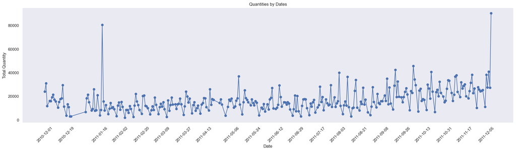

```python
plt.figure(figsize=(20, 6))
plt.plot(invoiceQuantities["InvoiceDate"], invoiceQuantities["Quantity"], marker="o")

plt.xticks(invoiceQuantities["InvoiceDate"][::15], rotation=45)  # Date labels every 15 days

plt.title("Quantities by Dates")
plt.xlabel("Date")
plt.ylabel("Total Quantity")
plt.grid()
plt.tight_layout()
plt.show()
```

- The figure shows that the quantities in the first and last months of 2011 were extremely high.

## Daily Analysis of Return Order Quantities

```python
filtered_df = df[df['InvoiceNo'].str.startswith('C')]
```

```python
invoiceQuantities = filtered_df.groupby("InvoiceDate")["Quantity"].sum().reset_index()
invoiceQuantities
```

|  | InvoiceDate | Quantity |
| --- | --- | --- |
| 0 | 2010-12-01 | -183 |
| 1 | 2010-12-02 | -10287 |
| 2 | 2010-12-03 | -291 |
| 3 | 2010-12-05 | -56 |
| 4 | 2010-12-06 | -196 |
| ... | ... | ... |
| 297 | 2011-12-05 | -123 |
| 298 | 2011-12-06 | -1095 |
| 299 | 2011-12-07 | -108 |
| 300 | 2011-12-08 | -639 |
| 301 | 2011-12-09 | -81030 |

302 rows × 2 columns

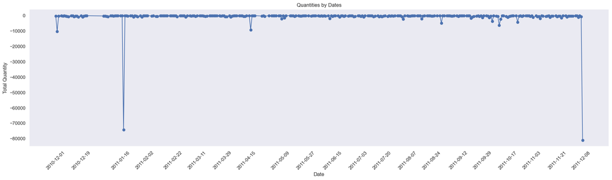

```python
plt.figure(figsize=(20, 6))
plt.plot(invoiceQuantities["InvoiceDate"], invoiceQuantities["Quantity"], marker="o")

plt.xticks(invoiceQuantities["InvoiceDate"][::15], rotation=45)  # Date labels every 15 days

plt.title("Quantities by Dates")
plt.xlabel("Date")
plt.ylabel("Total Quantity")
plt.grid()
plt.tight_layout()
plt.show()
```

- However, in terms of returns, this figure shows that the amounts in the first and last months of 2011 were again extremely high, nearly equal. On the other hand, the graph shows that the amount of refunds remained constant throughout the year.